# Dummyvariabelen in regressieanalyse

← Concepten in beeld

Bij regressieanalyse wil je het verband onderzoeken tussen een predictor en een uitkomstvariabele. Tot nu toe werkte je steeds met **kwantitatieve** predictoren: leeftijd, inkomen, studietijd. Maar wat als je predictor **categorisch** is? Denk aan onderwijstype (ASO, BSO, TSO), geslacht, of opleidingsniveau.

Je kan moeilijk “ASO” of “BSO” in een regressieformule stoppen — een formule verwacht getallen. De oplossing heet **dummy-codering**: je vertaalt een categorische variabele om naar één of meerdere variabelen die enkel de waarden 0 en 1 aannemen.

*Maar hoe werkt dat precies, en wat betekenen de regressiecoëfficiënten dan nog?* Scroll rustig naar beneden en we bouwen het stap voor stap op.

Heidi is een student die onderzoek doet voor haar bachelorproef. Ze vraagt zich af of het onderwijstype van leerlingen — ASO, BSO of TSO — een effect heeft op hun prestaties voor wiskunde. Ze heeft data verzameld bij 90 leerlingen.

De horizontale balkjes zijn de gemiddelden per groep. Het patroon is duidelijk: ASO-leerlingen scoren gemiddeld het hoogst, gevolgd door TSO en dan BSO.

*Maar kan Heidi dit verband nu gewoon onderzoeken met regressieanalyse?*

Dat is niet zo eenvoudig als het lijkt. Een regressiemodel werkt met een **formule**: $\hat{Y} = b_0 + b_1 \cdot X_1$. Die formule verwacht getallen. Je kan geen “ASO” of “BSO” invullen in een vermenigvuldiging.

We maken het eerst iets eenvoudiger. Stel dat Heidi enkel twee groepen vergelijkt: **ASO** en **BSO**.

*Hoe vertaal je “ASO” en “BSO” naar getallen die je in een regressieformule kan stoppen?*

Het antwoord is verrassend simpel: we maken een nieuwe variabele `dummy_BSO` die de waarde **1** krijgt als een leerling tot BSO behoort, en de waarde **0** als de leerling tot ASO behoort. Zo’n variabele noemen we een **dummyvariabele**.

Op de x-as staat nu onze dummyvariabele: 0 voor ASO-leerlingen (groen), 1 voor BSO-leerlingen (rood). De y-as toont nog steeds de wiskundescore.

*Dit ziet er al veel meer uit als een gewone scatterplot, nietwaar?*

Nu kunnen we een regressielijn tekenen door deze punten.

Dat is precies dezelfde regressielijn als altijd. Maar wat betekenen de coëfficiënten nu? Laat ons ze een voor een bekijken.

Het **intercept** $b_0$ (groen, links) is de voorspelde score wanneer `dummy_BSO = 0` — dus voor **ASO-leerlingen**. Dat is gewoon het gemiddelde van de referentiegroep: $b_0 = 14.64$.

De **helling** $b_1$ (rood, rechts) is het verschil in voorspelde score tussen `dummy_BSO = 1` en `dummy_BSO = 0` — dus het verschil in gemiddelde score tussen BSO en ASO: $b_1 = -4.68$.

De intercept is dus het **gemiddelde van de referentiegroep** (ASO), en de regressiecoëfficiënt is het **verschil** met die referentiegroep. De referentiegroep is altijd de groep die je codeert als 0.

*Maar Heidi heeft drie groepen. Hoe pakken we dat aan?*

Als je drie groepen hebt (ASO, BSO, TSO), maak je **twee** dummyvariabelen: één voor BSO (0 of 1) en één voor TSO (0 of 1). ASO blijft de referentiegroep — die herkent het model doordat beide dummies tegelijk 0 zijn.

Elke groep krijgt zo zijn eigen unieke combinatie van waarden: ASO-leerlingen scoren 0 op beide dummies, BSO-leerlingen scoren 1 op `dummy_BSO` en 0 op `dummy_TSO`, en TSO-leerlingen omgekeerd.

De intercept is nog steeds het gemiddelde van de referentiegroep (ASO = 14.64). $b_1$ is het verschil tussen BSO en ASO, $b_2$ het verschil tussen TSO en ASO.

*Maar waarom maken we geen drie dummies voor drie groepen?* Dat is de zogenaamde **dummy-trap**.

Wanneer de som van alle dummies altijd gelijk is aan 1, bevatten ze geen onafhankelijke informatie meer. Eén dummy is altijd volledig bepaald door de andere twee — hij is overbodig.

De vuistregel is daarom: gebruik altijd **k − 1 dummies** voor een categorische variabele met **k** categorieën. Eén categorie fungeert steeds als **referentiecategorie** (de categorie die je codeert als 0 op alle dummies).

In R hoef je dit trouwens niet zelf te doen. Als je een variabele als `factor()` definieert, past R de dummy-codering automatisch toe — en kiest het automatisch de eerste categorie (alfabetisch) als referentie.

In de output zie je `onderwijstypeBSO` en `onderwijstypeTSO` als coëfficiënten — dat zijn de twee dummies die R automatisch aanmaakte. **ASO** is de referentiegroep en verschijnt niet als aparte regel: de intercept is het gemiddelde voor ASO.

Zo heeft Heidi nu een volledig regressiemodel waarbij ze het effect van onderwijstype kan schatten — met correcte dummy-codering en een duidelijke referentiegroep.

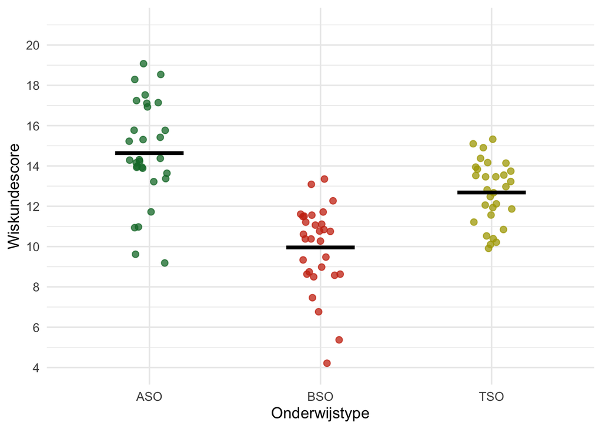

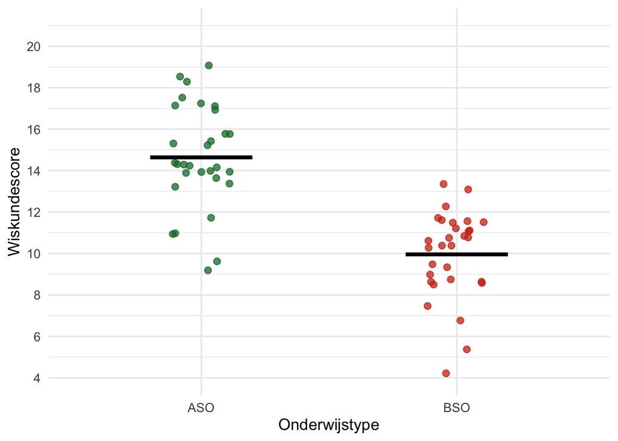

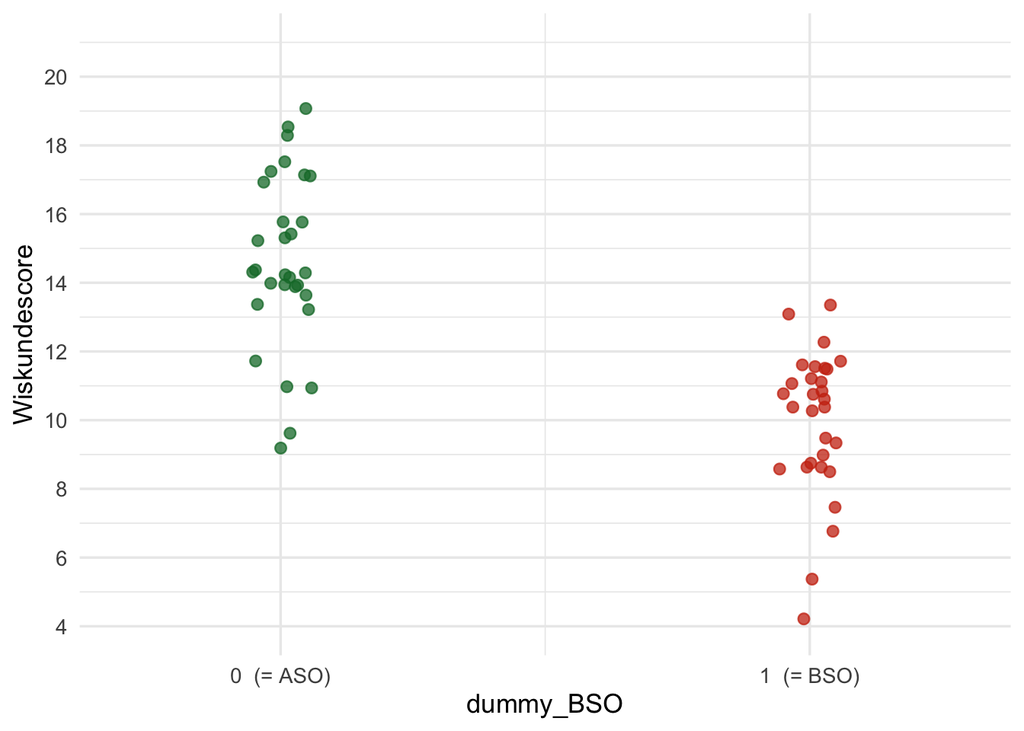

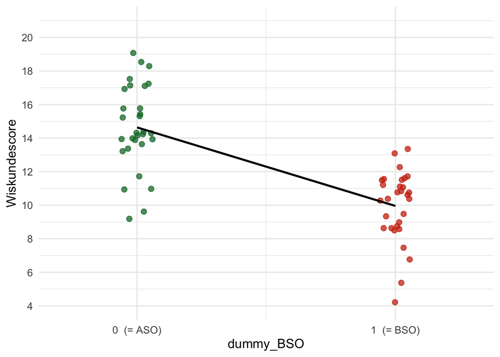

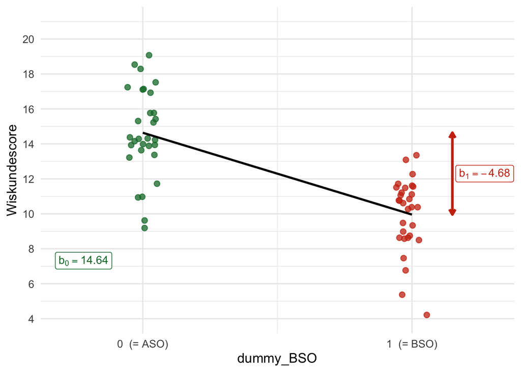

Het regressiemodel met één dummyvariabele ziet er zo uit:  
$\hat{\text{Score}}$ = **14.64** + **-4.68** × dummy_BSO  
Voor een ASO-leerling (dummy_BSO = 0): 14.64 + -4.68 × 0 = **14.64**  
Voor een BSO-leerling (dummy_BSO = 1): 14.64 + -4.68 × 1 = **9.96**

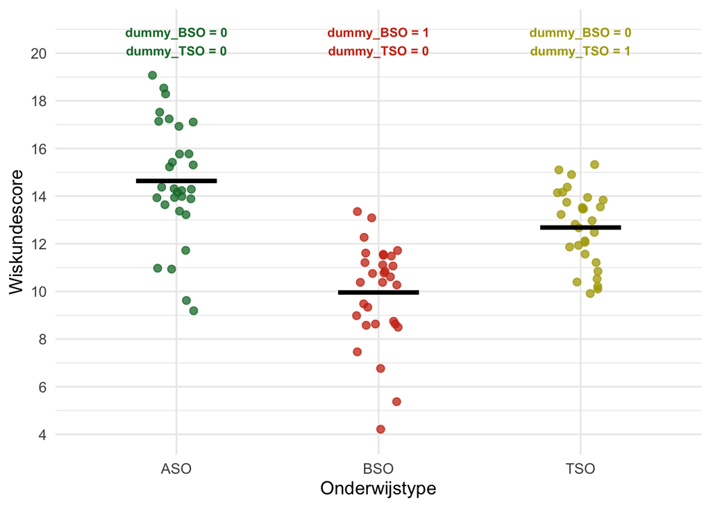

Het model met twee dummies:  
$\hat{\text{Score}}$ = **14.64** + **-4.68** × dummy_BSO + **-1.96** × dummy_TSO  
ASO (0, 0): 14.64 + -4.68×0 + -1.96×0 = **14.64**  
BSO (1, 0): 14.64 + -4.68×1 + -1.96×0 = **9.96**  
TSO (0, 1): 14.64 + -4.68×0 + -1.96×1 = **12.68**

Stel dat je drie dummies maakt:  
dummy_ASO + dummy_BSO + dummy_TSO  
Voor elke leerling geldt: één van de drie is 1, de andere twee zijn 0.  
Dus: dummy_ASO + dummy_BSO + dummy_TSO = **altijd 1**.  
De drie dummies bevatten geen nieuwe informatie meer —  
als je dummy_BSO en dummy_TSO kent, weet je dummy_ASO al.  
Dit noemen we **perfecte multicollineariteit**, en R kan het model  
dan niet schatten.

```r
# R past dummy-codering automatisch toe via factor()
Data <- Data %>%
  mutate(onderwijstype = factor(onderwijstype))

# Referentiecategorie bekijken (altijd de eerste)
levels(Data$onderwijstype)
```

```
[1] "ASO" "BSO" "TSO"
```

```r
# Model fitten: R maakt automatisch k-1 dummies aan
model <- lm(score ~ onderwijstype, data = Data)
summary(model)$coefficients %>% round(3)
```

```
                 Estimate Std. Error t value Pr(>|t|)
(Intercept)        14.637      0.382  38.271    0.000
onderwijstypeBSO   -4.681      0.541  -8.654    0.000
onderwijstypeTSO   -1.956      0.541  -3.616    0.001
```